# Einführung Zeitreihenanalyse

Karsten Lübke

## Euro Handelsdaten

Eurostat stellt viele Konjunkturdaten zur Verfügung, u. a. auch Handelsdaten [hier](https://datamarket.com/data/set/18tp/retail-trade-quarterly-data-nace-rev-2#!display=line&ds=18tp!mqw=2:mqz=y). Diese finden sich im Datensatz `euretail` des Paktes `fpp`:

```r
# Einmalig installieren:
# install.packages("fpp")

library(fpp) # Paket laden
data(euretail) # Datensatz laden
euretail
```

```
##        Qtr1   Qtr2   Qtr3   Qtr4
## 1996  89.13  89.52  89.88  90.12
## 1997  89.19  89.78  90.03  90.38
## 1998  90.27  90.77  91.85  92.51
## 1999  92.21  92.52  93.62  94.15
## 2000  94.69  95.34  96.04  96.30
## 2001  94.83  95.14  95.86  95.83
## 2002  95.73  96.36  96.89  97.01
## 2003  96.66  97.76  97.83  97.76
## 2004  98.17  98.55  99.31  99.44
## 2005  99.43  99.84 100.32 100.40
## 2006  99.88 100.19 100.75 101.01
## 2007 100.84 101.34 101.94 102.10
## 2008 101.56 101.48 101.13 100.34
## 2009  98.93  98.31  97.67  97.44
## 2010  96.53  96.56  96.51  96.70
## 2011  95.88  95.84  95.79  95.97
```

Es handelt sich also um quartalsweise Daten von 1996, 1 bis 2011, 4.

```r
class(euretail)
```

```
## [1] "ts"
```

`ts` steht dabei für ein Zeitreihenobjekt in R. Zeitreihen (d. h. eine Folge von Beobachtungen mit der Zeit – der Wert variiert mit der Zeit) haben viele Besonderheiten, die zur Analyse genutzt werden können.

```r
start(euretail) # Startbeobachtung
```

```
## [1] 1996    1
```

```r
end(euretail) # Endbeobachtung
```

```
## [1] 2011    4
```

```r
frequency(euretail) # Beobachtungen je Zeiteinheit
```

```
## [1] 4
```

Eine Abbildung kann wie üblich einfach über `plot()` erzeugt werden.

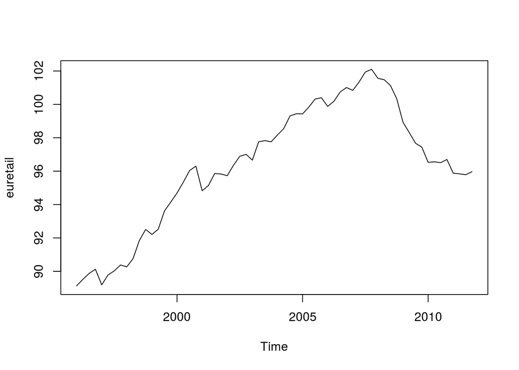

```r
plot(euretail)
```

Man erkennt einen Anstieg bis ca. 2008 (Finanzkrise!), dann einen Abschwung und ab 2010/11 eine evt. Erholung – aber auch saisonale Schwankungen.

## Zeitreihenzerlegung

Eine Zeitreihe (`data`) $y_t$ kann in verschiedene Komponenten zerlegt werden:

- Trend (`trend`) $M_t$
- Saisonkomponenten (`seasonal`)$S_t$
- Rest-/ Fehlerkomponenten (`remainder`) $E_t$

Das *additive* Modell lautet dann einfach:
$$Y_t=M_t+S_t+E_t$$
während das *multiplikative* Modell lautet
$$Y_t=M_t \cdot S_t \cdot E_t.$$
Es gibt viele Möglichkeiten $m_t, s_t, z_t$ zu schätzen, eine gute Umsetzung findet sich in der Funktion `stl()` Hier muss die Option `s.window=` angegeben werden. (Eine Alternative ohne Option ist `decompose()`)

```r
fit <- stl(euretail, s.window = 5)
fit
```

```
##  Call:
##  stl(x = euretail, s.window = 5)
##
## Components
##             seasonal     trend    remainder
## 1996 Q1 -0.419860564  89.57375 -0.023884485
## 1996 Q2 -0.123565509  89.62061  0.022953668
## 1996 Q3  0.193599124  89.66846  0.017942030
## 1996 Q4  0.346353935  89.71844  0.055205774
## 1997 Q1 -0.404246348  89.76781 -0.173568415
## 1997 Q2 -0.147484780  89.85132  0.076164034
## 1997 Q3  0.198861912  90.01958 -0.188446028
## 1997 Q4  0.343940521  90.28854 -0.252483392
## 1998 Q1 -0.349545254  90.65637 -0.036827055
## 1998 Q2 -0.238674319  91.11372 -0.105046188
```

[output cut: 54 more lines]

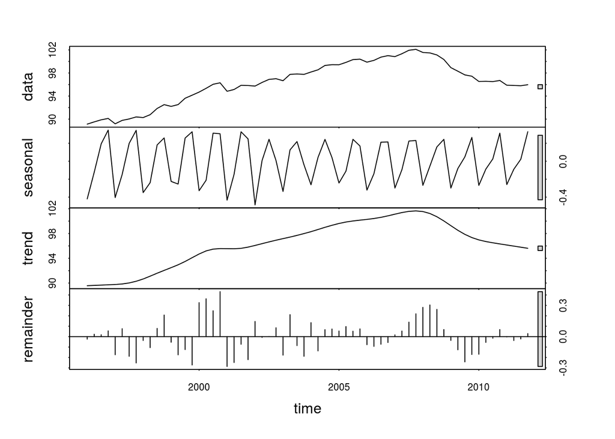

```r
plot(fit)
```

Es gibt eine klare Trendwende in 2008 sowie deutliche Saisoneffekte: der Handel ist am niedrigsten in Q1, am höchsten in Q4.

Eine solche Zerlegung kann übrigens auch als Basis einer Prognose verwendet werden – dabei werden sogar die Prognoseintervalle berechnet. Für Details zur Prognose siehe `?ets`.

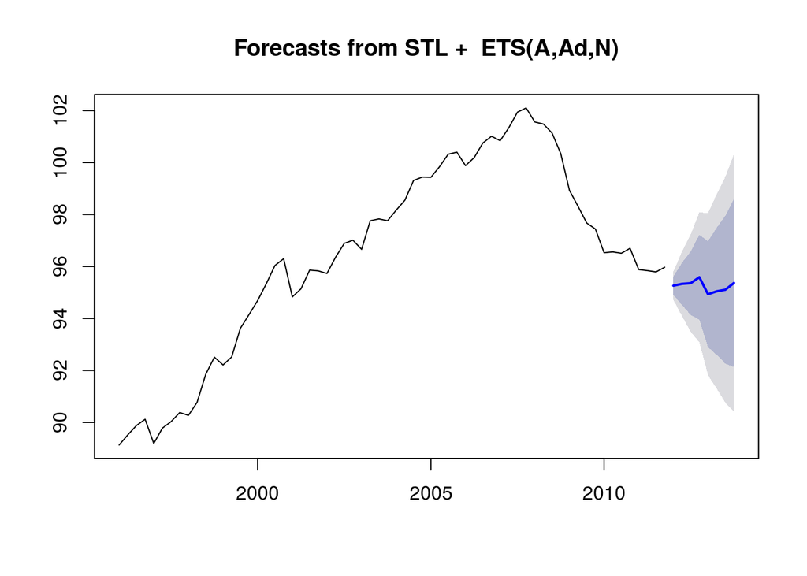

```r
prog <- predict(fit)
plot(prog)
```

## Gleitende Durchschnitte

Eine einfache Möglichkeit eine Zeitreihe zu glätten, sind gleitende Durchschnitte (moving-average, Funktion `ma()` aus dem Paket `forecast`). Dazu wird einfach der Mittelwert der $q$ Beobachtungen vor und nach $t$, inkl. $t$, berechnet:
$$\hat{y}_{q,t}:=\frac{1}{p}\sum_{j=-q}^{q}y_{t+j}$$
mit $p=2q+1$.

Je größer $q$ (`order`) ist, desto glatter wird die Zeitreihe:

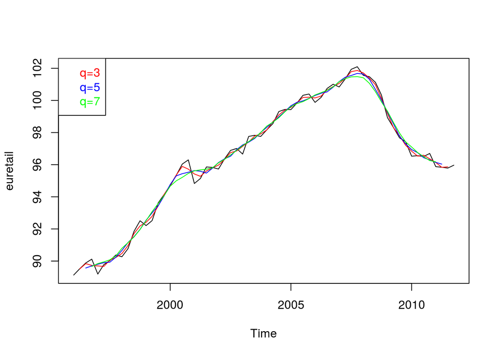

```r
plot(euretail)
lines(ma(euretail, order=3), col="red")
lines(ma(euretail, order=5), col="blue")
lines(ma(euretail, order=7), col="green")
legend("topleft", legend=c("q=3", "q=5", "q=7"), text.col=c("red", "blue", "green"))
```

## Übung: Produktionsdaten

Der Datensatz `elecequip` aus dem Paket `fpp` enthält monatliche Produktionsdaten von elektronischen Equipment (näheres siehe [hier](https://datamarket.com/data/set/19gk/industry-new-orders-index-monthly-data-2005100-nace-rev2#!display=line&ds=19gk!orw=1d:orx=4:ory=4.c.8.w.z.a.k.s.l.6.9.r.e.g.u.d.n.7.p.t.1.m.i.f.3.j.v.q.2)).

Wie würden Sie die Zeitreihe beschreiben?

## Literatur

- Paul S. P. Cowpertwait, Andrew V. Metcalfe (2009): *Introductory Time Series with R*, Kapitel 1
- Rob J. Hyndman, George Athanasopoulos (2012): *Forecasting: principles and practice*, https://www.otexts.org/fpp, Kapitel 6
- Rainer Schlittgen (2012): *Angewandte Zeitreihenanalyse mit R*, Kapitel 2

### Lizenz

Diese Übung wurde von Karsten Lübke entwickelt und steht unter der Lizenz [Creative Commons Attribution-ShareAlike 3.0 Unported](http://creativecommons.org/licenses/by-sa/3.0).

### Versionshinweise:

- Datum erstellt: 2017-03-27
- R Version: 3.3.3